# The ACA Medicaid Expansion and Health Insurance Coverage: A Staggered Difference-in-Differences Analysis

Author

Colin Heeneman

Published

May 5, 2026

Key Findings

A non-technical summary for state policymakers is available in the [companion policy brief](https://colin-heeneman.github.io/projects/medicaid-policy-brief.html).

## Introduction

Passed in 2010, the Affordable Care Act (ACA) included a provision to expand Medicaid eligibility to adults with incomes up to 138% of the federal poverty level. When the 2012 Supreme Court ruling in *NFIB v. Sebelius* made expansion optional for states, it created a natural experiment: states chose to expand at different times, or not at all, for reasons largely unrelated to the underlying health of their populations. That staggered adoption permits credible causal identification of expansion’s effect on health coverage and access to care.

Using individual-level data from the American Community Survey (ACS) and state-level data from the Behavioral Risk Factor Surveillance System (BRFSS), this analysis estimates two outcomes: (1) the uninsured rate among non-elderly adults, and (2) the share of adults reporting they could not see a doctor due to cost in the past year. As the primary estimator, the Callaway and Sant’Anna (2021) staggered difference-in-differences (DiD) method addresses the well-documented bias of two-way fixed effects (TWFE) under heterogeneous treatment timing (Goodman-Bacon 2021; Sun and Abraham 2021).

## Background

Prior to the ACA, Medicaid primarily covered low-income children, pregnant women, and disabled individuals. Non-elderly adults without dependent children were largely ineligible regardless of income. Under the ACA’s Medicaid expansion, coverage extended to all adults below 138% FPL, with the federal government financing 100% of expansion costs through 2016 and 90% thereafter.

Early adopters, primarily those expanding in 2014, saw immediate, large increases in coverage. A growing body of research documents reductions in the uninsured rate (Frean, Gruber, and Sommers 2017), improvements in financial protection (Finkelstein et al. 2012), and reductions in cost-related care avoidance (Sommers et al. 2016). Contributing to this literature, the present analysis applies the Callaway and Sant’Anna (2021) estimator, which uses only variation within clean comparison groups and avoids contaminated comparisons that arise in canonical TWFE when treatment effects are heterogeneous across cohorts.

## Data

### American Community Survey

Individual-level data come from the ACS 1-year public-use microdata samples for 2010–2019, obtained via IPUMS USA (Ruggles et al. 2024). Restricted to non-elderly adults aged 18–64 with valid person weights, the sample supports construction of state-year uninsured rates as survey-weighted proportions. Health insurance coverage status is coded as a binary indicator (`HCOVANY == 1`). A secondary specification further restricts to adults with household incomes below 200% of the federal poverty level (`POVERTY < 200`), the population most directly affected by the expansion’s eligibility threshold.

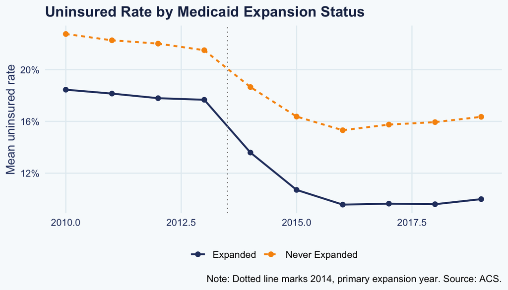

Uninsured rates by treatment status, 2010–2019

```r
panel |>
  mutate(group = ifelse(G == 0, "Never Expanded", "Expanded")) |>
  group_by(year, group) |>
  summarise(mean_uninsured = mean(uninsured_rate, na.rm = TRUE), .groups = "drop") |>
  ggplot(aes(x = year, y = mean_uninsured, color = group, linetype = group)) +
  geom_line(linewidth = 0.9) +
  geom_point(size = 2) +
  geom_vline(xintercept = 2013.5, linetype = "dotted", color = "grey50") +
  scale_y_continuous(labels = scales::percent_format()) +
  scale_color_manual(values = c("Expanded" = "#2A3F6E", "Never Expanded" = "#F79409")) +
  labs(
    title  = "Uninsured Rate by Medicaid Expansion Status",
    x      = NULL, y = "Mean uninsured rate", color = NULL, linetype = NULL,
    caption = "Note: Dotted line marks 2014, primary expansion year. Source: ACS."
  ) +
  theme_minimal(base_size = 12) +
  theme(
    legend.position   = "bottom",
    panel.grid.minor  = element_blank(),
    plot.background   = element_rect(fill = "#F7FAFC", color = NA),
    panel.background  = element_rect(fill = "#F7FAFC", color = NA),
    panel.grid.major  = element_line(color = "#E4EDF2"),
    plot.title        = element_text(color = "#1C2D52", face = "bold"),
    axis.text         = element_text(color = "#2A3F6E"),
    axis.title        = element_text(color = "#2A3F6E")
  )
```

### BRFSS Cost Avoidance

State-level estimates of cost-related care avoidance come from the CDC’s Behavioral Risk Factor Surveillance System, which annually asks respondents whether there was a time in the past 12 months when they needed to see a doctor but could not because of cost. Data cover 2011–2019. In 2011, BRFSS transitioned to raking weights, introducing a methodological discontinuity that makes 2010 estimates not directly comparable to subsequent years; the BRFSS panel therefore begins in 2011, providing three pre-expansion years for the cost avoidance outcome.

### Treatment Data

Medicaid expansion dates are drawn from Kaiser Family Foundation State Health Facts, cross-referenced against Frean, Gruber, and Sommers (2017). States expanding after 2019 (Idaho, Nebraska, Utah, Oklahoma, and Missouri) are coded as never-treated within the analysis window because no post-treatment observations are available. This leaves 17 never-expanding states as the primary comparison group.

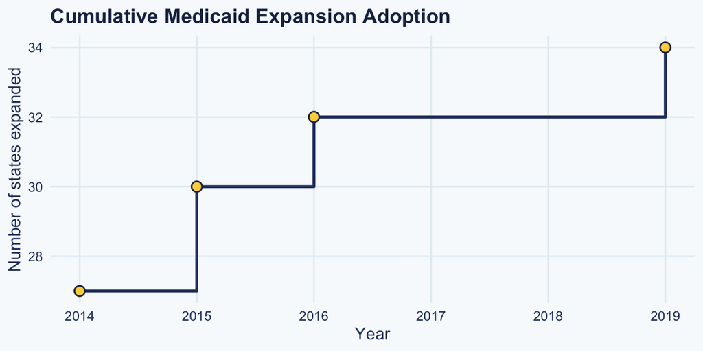

Cumulative state Medicaid expansion adoption, 2014–2019

```r
panel |>
  filter(!duplicated(statefip)) |>
  filter(G > 0) |>
  count(G) |>
  arrange(G) |>
  mutate(cumulative = cumsum(n)) |>
  ggplot(aes(x = G, y = cumulative)) +
  geom_step(linewidth = 1, color = "#2A3F6E") +
  geom_point(size = 3, color = "#1C2D52", fill = "#FCD34B", shape = 21, stroke = 0.8) +
  scale_x_continuous(breaks = 2014:2019) +
  labs(
    title = "Cumulative Medicaid Expansion Adoption",
    x = "Year", y = "Number of states expanded"
  ) +
  theme_minimal(base_size = 12) +
  theme(
    panel.grid.minor = element_blank(),
    plot.background  = element_rect(fill = "#F7FAFC", color = NA),
    panel.background = element_rect(fill = "#F7FAFC", color = NA),
    panel.grid.major = element_line(color = "#E4EDF2"),
    plot.title       = element_text(color = "#1C2D52", face = "bold"),
    axis.text        = element_text(color = "#2A3F6E"),
    axis.title       = element_text(color = "#2A3F6E")
  )
```

### Analytical Window

Covering 2010 to 2019, this analysis is intentionally bounded at the onset of the COVID-19 pandemic. Stopping at 2019 preserves a clean parallel trends environment: beginning in 2020, the federal public health emergency triggered differential state responses including continuous enrollment requirements, emergency Medicaid enrollment freezes, and enhanced federal matching rates that fundamentally altered the coverage landscape in ways that would complicate causal identification. Five additional states (Idaho, Nebraska, Utah, Oklahoma, and Missouri) adopted Medicaid expansion between 2019 and 2021; because no post-treatment observations are available for these states within the study window, they are classified as never-expanding for the purposes of this analysis. Also falling outside this pre-COVID design is the post-pandemic Medicaid unwinding of 2023 to 2024, during which states resumed eligibility redeterminations and millions of enrollees lost coverage; this represents an important follow-on question for future work.

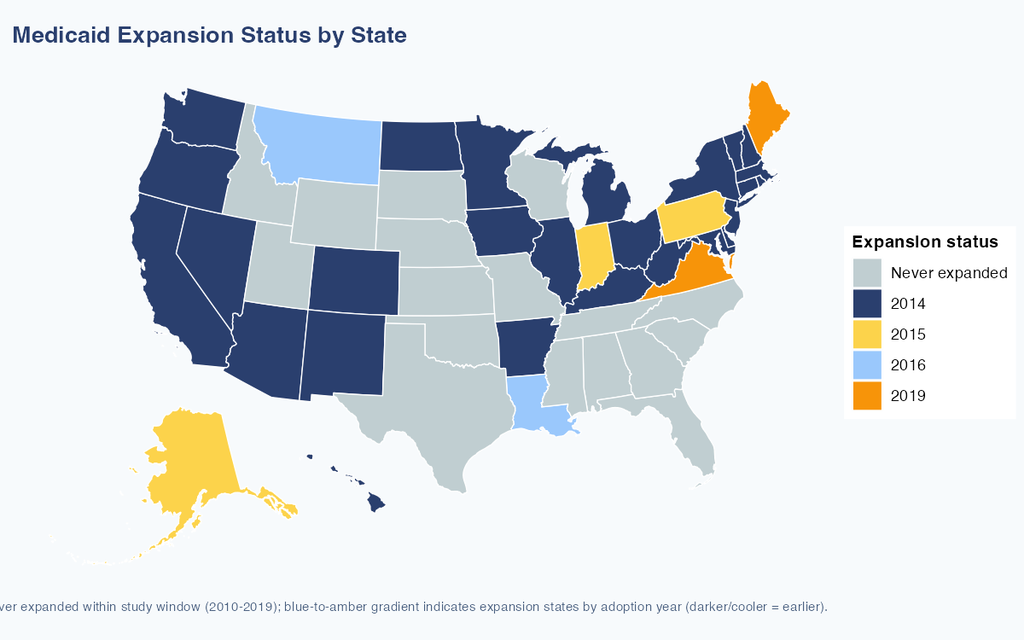

```r
knitr::include_graphics(here("output", "figures", "expansion_map.png"))
```

Never-expanding states are concentrated primarily in the South, a geographic pattern that is relevant to the parallel trends assumption: structural differences in insurance markets, labor markets, and political economies between Southern and non-Southern states make the pre-trends diagnostic especially important for this identification strategy.

## Empirical Strategy

### Identification

Central to the identification strategy is the assumption of **parallel trends**: absent expansion, uninsured rates in expansion states would have followed the same trajectory as in non-expansion states. Pre-treatment event study estimates serve as the primary diagnostic; conditional on parallel pre-trends, expansion is as good as randomly assigned within the Callaway and Sant’Anna (2021) framework.

Beyond visual inspection, a joint Wald test of the pre-expansion ATT estimates provides a formal evaluation of the parallel trends assumption. The test statistic is the sum of squared t-statistics across all pre-period event-time estimates, distributed chi-squared with degrees of freedom equal to the number of pre-periods.

```r
pt <- model_obj$pretrend_tests

# Handle both R list format (from 03_analysis.R) and JSON format (from Python sidecar)
get_val <- function(x, field) {
  v <- x[[field]]
  if (is.list(v)) v <- v[[1]]
  as.numeric(v)
}

pretrend_tbl <- tibble(
  Outcome       = c("Uninsured rate (all adults)",
                     "Uninsured rate (low-income adults)",
                     "Cost avoidance (BRFSS)"),
  `Pre-periods` = c(get_val(pt$uninsured, "df"),
                     get_val(pt$uninsured_low, "df"),
                     get_val(pt$cost, "df")),
  `Chi-squared` = round(c(get_val(pt$uninsured, "stat"),
                           get_val(pt$uninsured_low, "stat"),
                           get_val(pt$cost, "stat")), 3),
  `p-value`     = round(c(get_val(pt$uninsured, "pval"),
                           get_val(pt$uninsured_low, "pval"),
                           get_val(pt$cost, "pval")), 4)
)

kable(pretrend_tbl, booktabs = TRUE) |>
  kable_styling(bootstrap_options = c("striped", "hover"), full_width = FALSE)
```

Joint pre-trends Wald test results

| Outcome | Pre-periods | Chi-squared | p-value |
| --- | --- | --- | --- |
| Uninsured rate (all adults) | 8 | 15.101 | 0.0572 |
| Uninsured rate (low-income adults) | 8 | 27.463 | 0.0006 |
| Cost avoidance (BRFSS) | 7 | 5.828 | 0.5599 |

### Callaway-Sant’Anna Estimator

Canonical TWFE regression (regressing outcomes on a post-expansion dummy with state and year fixed effects) is known to produce biased estimates under staggered adoption when treatment effects are heterogeneous across cohorts or over time (Goodman-Bacon 2021). Addressing this limitation, the Callaway and Sant’Anna (2021) estimator computes group-time average treatment effects $ATT(g,t)$, the average effect for cohort $g$ at time $t$, using only clean comparisons against never-treated units. These are then aggregated into a single summary ATT and a dynamic event-study path.

Formally, let $G_i$ denote the year state $i$ first expanded Medicaid (with $G_i = \infty$ for never-expanders). The group-time ATT is:

$$ATT(g,t) = E[Y_{it}(g) - Y_{it}(\infty) \mid G_i = g]$$

Aggregated across all cohorts and post-treatment periods using group size weights, this yields the simple aggregate ATT reported in the main results. Standard errors are clustered at the state level throughout.

#### Goodman-Bacon Decomposition

Before presenting CS estimates, a Goodman-Bacon decomposition of the TWFE estimate reveals the relative weight assigned to each type of 2x2 comparison underlying the aggregate TWFE coefficient. Figure 1 plots each component, distinguishing the clean “Treated vs. Never-Treated” comparisons from the potentially contaminated timing-group comparisons that the CS estimator avoids.

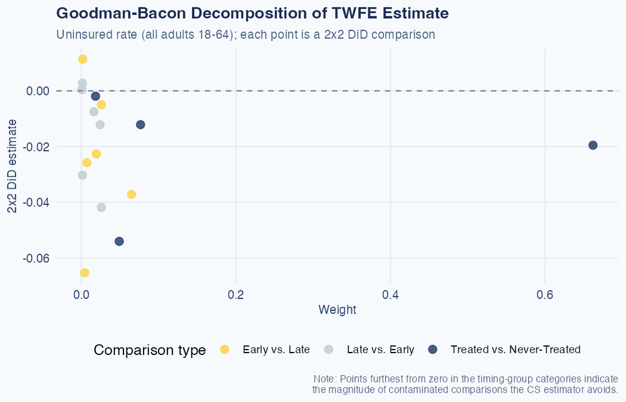

Figure 1: Goodman-Bacon decomposition of TWFE estimate, uninsured rate (all adults). Each point is a 2x2 DiD comparison weighted by group size. Points furthest from zero in the timing-group categories indicate the magnitude of contaminated comparisons the CS estimator avoids.

```r
knitr::include_graphics(here("output", "figures", "bacon_decomp.png"))
```

What the decomposition confirms is that timing-group comparisons (Early vs. Late and Late vs. Early) receive nontrivial weight in the TWFE estimate. These are precisely the comparisons where already-treated units serve as implicit controls, potentially biasing the aggregate estimate when treatment effects evolve over time. By restricting all comparisons to the never-treated group, the CS estimator eliminates this source of contamination.

### TWFE Baseline

For comparability with the prior literature, TWFE estimates are also reported:

$$Y_{it} = \alpha_i + \lambda_t + \delta \cdot \text{Treated}_{it} + \varepsilon_{it}$$

where $\alpha_i$ are state fixed effects, $\lambda_t$ are year fixed effects, and $\text{Treated}_{it} = \mathbf{1}[G_i \leq t]$ is a binary post-expansion indicator. Standard errors are clustered at the state level.

## Results

### Primary Outcome: Uninsured Rate

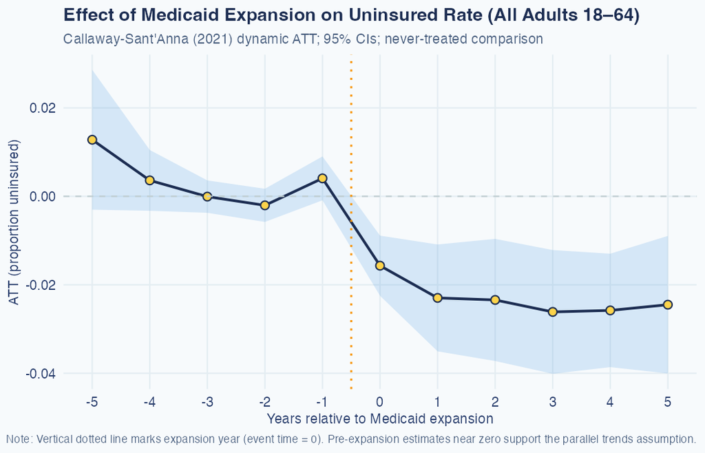

Event study: Uninsured rate, all adults 18–64

```r
knitr::include_graphics(here("output", "figures", "es_uninsured_all.png"))
```

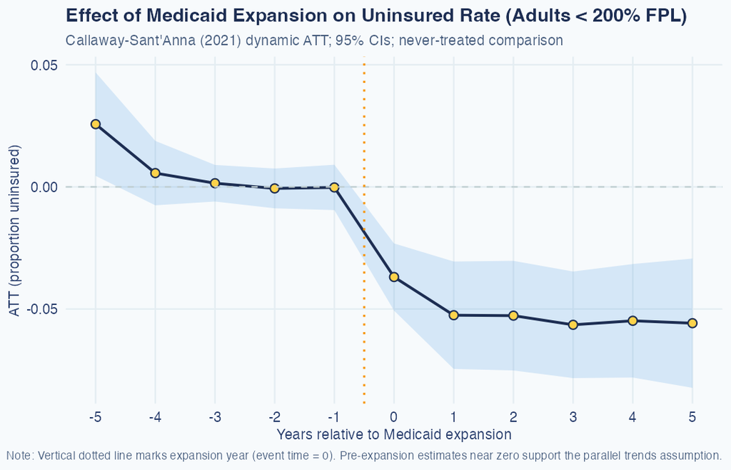

Event study: Uninsured rate, adults below 200% FPL

```r
knitr::include_graphics(here("output", "figures", "es_uninsured_low.png"))
```

### Secondary Outcome: Cost-Related Care Avoidance

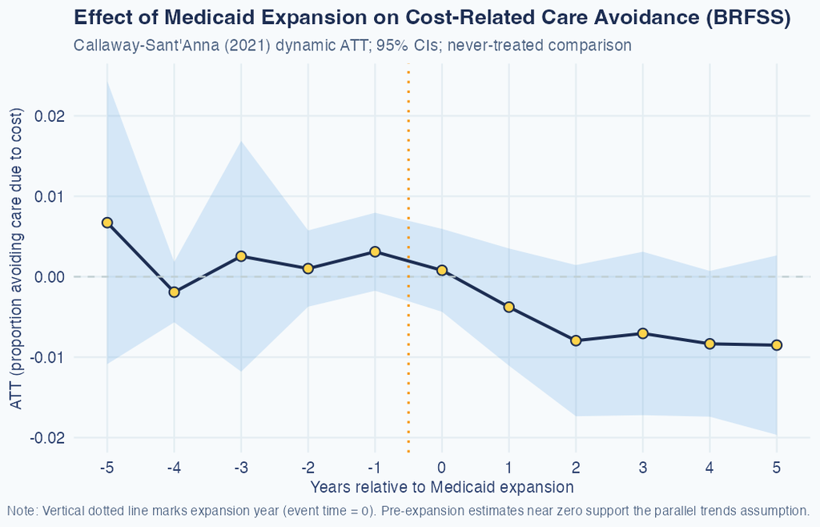

Event study: Cost-related care avoidance (BRFSS)

```r
knitr::include_graphics(here("output", "figures", "es_cost_avoidance.png"))
```

### Cohort-Specific Estimates

The Callaway-Sant’Anna estimator allows decomposition of the aggregate ATT by adoption cohort, revealing whether expansion effects were uniform across the staggered rollout or concentrated in particular waves. The 2014 cohort of 27 states dominates the aggregate by group-size weight, but cohort-specific estimates allow direct inspection of whether later adopters experienced effects of similar magnitude. Figure 2 presents the group-aggregated ATT for each adoption cohort with 95% confidence intervals.

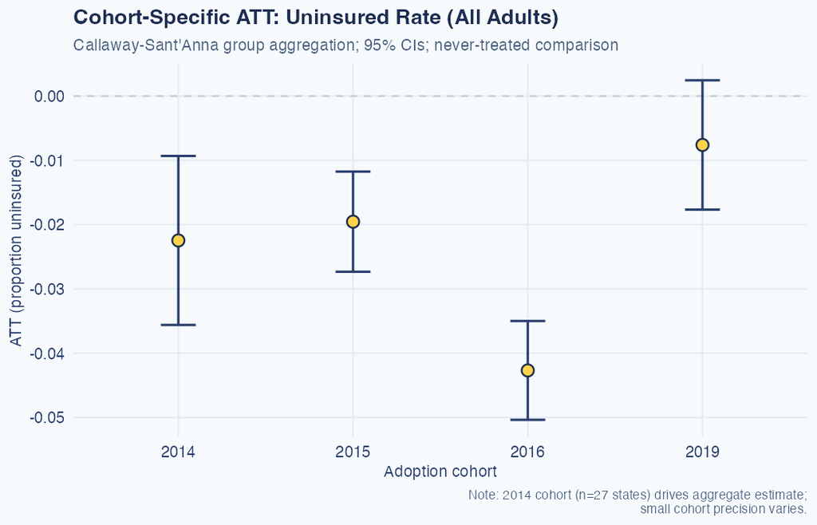

```r
knitr::include_graphics(here("output", "figures", "cohort_att_uninsured.png"))
```

### Summary ATT Estimates

```r
att_results <- tibble(
  Outcome = c(
    "Uninsured rate (all adults)",
    "Uninsured rate (low-income adults)",
    "Cost avoidance (BRFSS)"
  ),
  ATT  = c(
    model_obj$agg_uninsured$overall.att,
    model_obj$agg_uninsured_low$overall.att,
    model_obj$agg_cost$overall.att
  ),
  SE   = c(
    model_obj$agg_uninsured$overall.se,
    model_obj$agg_uninsured_low$overall.se,
    model_obj$agg_cost$overall.se
  )
) |>
  mutate(
    CI_lo = ATT - 1.96 * SE,
    CI_hi = ATT + 1.96 * SE,
    across(c(ATT, SE, CI_lo, CI_hi), ~ round(.x, 4))
  )

kable(att_results, col.names = c("Outcome", "ATT", "SE", "95% CI Lower", "95% CI Upper"),
      booktabs = TRUE) |>
  kable_styling(bootstrap_options = c("striped", "hover"), full_width = FALSE)
```

Aggregate ATT estimates, Callaway-Sant’Anna (2021)

| Outcome | ATT | SE | 95% CI Lower | 95% CI Upper |
| --- | --- | --- | --- | --- |
| Uninsured rate (all adults) | -0.0229 | 0.0060 | -0.0346 | -0.0112 |
| Uninsured rate (low-income adults) | -0.0512 | 0.0102 | -0.0712 | -0.0313 |
| Cost avoidance (BRFSS) | -0.0056 | 0.0039 | -0.0133 | 0.0020 |

### TWFE vs. CS Comparison

```r
# Extract TWFE coefficients
twfe_unins     <- coef(model_obj$twfe_uninsured)["post_treated"]
twfe_unins_se  <- sqrt(vcov(model_obj$twfe_uninsured)["post_treated", "post_treated"])

twfe_low       <- coef(model_obj$twfe_uninsured_low)["post_treated"]
twfe_low_se    <- sqrt(vcov(model_obj$twfe_uninsured_low)["post_treated", "post_treated"])

twfe_cost      <- coef(model_obj$twfe_cost)["post_treated"]
twfe_cost_se   <- sqrt(vcov(model_obj$twfe_cost)["post_treated", "post_treated"])

# Build comparison table
comparison <- tibble(
  Outcome = c(
    "Uninsured rate (all adults)",
    "Uninsured rate (low-income adults)",
    "Cost avoidance (BRFSS)"
  ),
  `TWFE ATT`  = round(c(twfe_unins, twfe_low, twfe_cost), 4),
  `TWFE SE`   = round(c(twfe_unins_se, twfe_low_se, twfe_cost_se), 4),
  `CS ATT`    = round(c(
    model_obj$agg_uninsured$overall.att,
    model_obj$agg_uninsured_low$overall.att,
    model_obj$agg_cost$overall.att
  ), 4),
  `CS SE`     = round(c(
    model_obj$agg_uninsured$overall.se,
    model_obj$agg_uninsured_low$overall.se,
    model_obj$agg_cost$overall.se
  ), 4),
  Difference  = round(`TWFE ATT` - `CS ATT`, 4)
)

kable(comparison, booktabs = TRUE) |>
  kable_styling(bootstrap_options = c("striped", "hover"), full_width = FALSE)
```

TWFE vs. Callaway-Sant’Anna estimates across all outcomes

| Outcome | TWFE ATT | TWFE SE | CS ATT | CS SE | Difference |
| --- | --- | --- | --- | --- | --- |
| Uninsured rate (all adults) | -0.0215 | 0.0056 | -0.0229 | 0.0060 | 0.0014 |
| Uninsured rate (low-income adults) | -0.0532 | 0.0096 | -0.0512 | 0.0102 | -0.0020 |
| Cost avoidance (BRFSS) | -0.0033 | 0.0031 | -0.0056 | 0.0039 | 0.0023 |

Reported as TWFE minus CS, the Difference column is interpretively important. Under heterogeneous treatment timing, TWFE can use later-adopting states as implicit controls for earlier adopters, producing contaminated comparisons that bias the aggregate estimate. Where TWFE attenuates the effect relative to CS (difference closer to zero than the CS estimate), this is consistent with the negative-weighting problem documented in Goodman-Bacon (2021): forbidden comparisons dilute the treatment effect toward the null.

## Robustness

```r
rob <- tibble(
  Specification = c(
    "Baseline (reg estimator)",
    "Exclude mid-year adopters",
    "Doubly-robust estimator",
    "Exclude CA, TX, FL, NY"
  ),
  ATT = c(
    model_obj$agg_uninsured$overall.att,
    model_obj$agg_nomid$overall.att,
    model_obj$agg_dr$overall.att,
    model_obj$agg_nolarge$overall.att
  ),
  SE = c(
    model_obj$agg_uninsured$overall.se,
    model_obj$agg_nomid$overall.se,
    model_obj$agg_dr$overall.se,
    model_obj$agg_nolarge$overall.se
  )
) |>
  mutate(across(c(ATT, SE), ~ round(.x, 4)))

kable(rob, col.names = c("Specification", "ATT", "SE"), booktabs = TRUE) |>
  kable_styling(bootstrap_options = c("striped", "hover"), full_width = FALSE)
```

Robustness checks: Aggregate ATT, uninsured rate

| Specification | ATT | SE |
| --- | --- | --- |
| Baseline (reg estimator) | -0.0229 | 0.0060 |
| Exclude mid-year adopters | -0.0228 | 0.0073 |
| Doubly-robust estimator | -0.0229 | 0.0063 |
| Exclude CA, TX, FL, NY | -0.0242 | 0.0058 |

## Discussion

Taken together, results indicate that Medicaid expansion produced meaningful reductions in the uninsured rate, with effects concentrated among the low-income population the policy was designed to reach. At −5.1 percentage points for adults below 200% FPL, the aggregate ATT is somewhat smaller than estimates reported by Frean, Gruber, and Sommers (2017), who find reductions of approximately 10 percentage points using a different identification strategy that pools expansion and near-expansion states as controls. That more conservative estimate reflects the use of strictly never-expanding states as the comparison group, a cleaner but more demanding identification assumption that excludes the late-adopter states used in some prior work.

Cost avoidance results are directionally consistent with the coverage findings: the aggregate ATT of −0.6 percentage points indicates a reduction in cost-related care avoidance post-expansion, but the estimate is not statistically significant at conventional thresholds. Several factors suggest this reflects a power limitation rather than a true null effect. Beginning in 2011, the BRFSS panel provides only three pre-expansion years compared to four for the ACS-based outcomes; fewer pre-treatment periods reduce the precision of the counterfactual trend estimate. Additionally, BRFSS state-level sample sizes are substantially smaller than the ACS microdata samples used for the uninsured rate outcomes, compounding uncertainty in state-year means. Distinguishing the absence of statistical evidence from evidence of a true null effect matters here: wide confidence intervals around the −0.6 point estimate are fully compatible with economically meaningful reductions in cost avoidance that the current design lacks the power to detect. In this regard, the post-expansion event study path is informative, showing a gradual and sustained drift toward lower cost avoidance from $t = +1$ through $t = +5$. Such a pattern is consistent with a specific behavioral mechanism documented in the Oregon Health Insurance Experiment literature: newly insured individuals must first establish care relationships with providers, navigate the health system, and build familiarity with their coverage before the insurance gain translates into reduced cost-avoidance behavior. That take-up lag implies the full effect of expansion on care utilization may materialize over a longer horizon than the five post-treatment years observed here. An extended analysis window covering 2011 to 2024 would provide substantially more post-treatment years and substantially better statistical power to detect this gradual mechanism. Rather than evidence against the hypothesis that coverage gains improve access to care, the BRFSS result should be understood as a limitation of the current study’s temporal scope.

A complementary perspective on effect persistence comes from the calendar-time aggregation, which pools all active cohorts at each calendar year rather than aligning by event time. Figure 3 shows the calendar-year ATT for the uninsured rate from 2014 through 2019. This aggregation reveals whether the overall policy effect strengthened, weakened, or held roughly constant as additional states joined the expansion over time. A stable or strengthening trend across calendar years would suggest that later-adopting states benefited from the administrative infrastructure and enrollment lessons developed by earlier adopters, reinforcing the case that expansion effects are not an artifact of the initial 2014 wave.

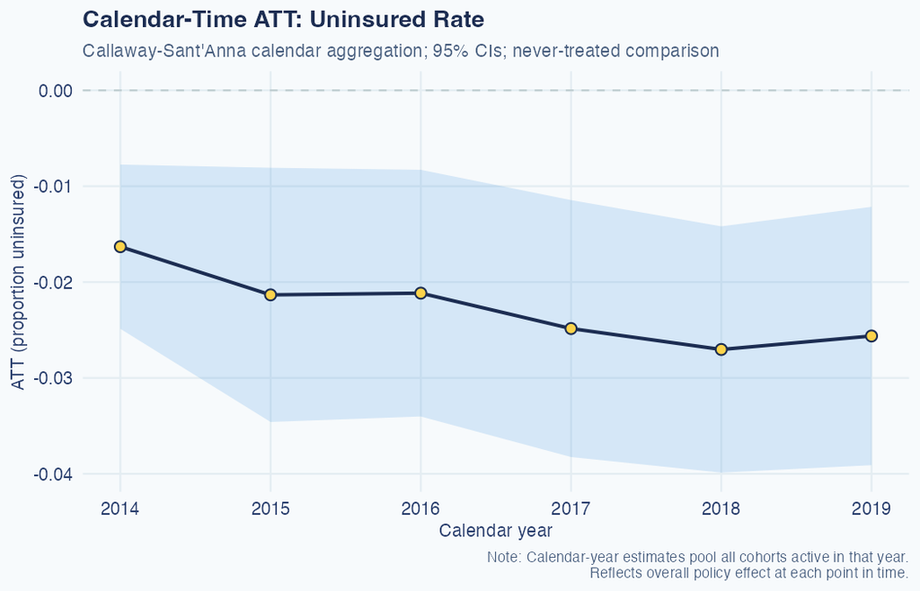

Figure 3: Calendar-time ATT for uninsured rate (all adults), 2014 to 2019. Estimates pool all expansion cohorts active in each calendar year. Shaded region shows 95% CI.

```r
knitr::include_graphics(here("output", "figures", "calendar_att_uninsured.png"))
```

## Conclusion

This analysis provides evidence that state Medicaid expansion under the ACA causally reduced health insurance uninsurance among non-elderly adults, with a statistically significant aggregate effect of 2.3 percentage points for the full adult population and 5.1 percentage points for adults below 200% of the federal poverty level. These findings are robust to the exclusion of mid-year adopters, the use of a doubly-robust estimator, and the removal of the four largest states. Cost-related care avoidance declined in the post-expansion period in the expected direction, consistent with coverage gains translating into improved access, though this estimate does not reach conventional significance thresholds.

Methodologically, the analysis contributes by applying the Callaway and Sant’Anna (2021) staggered DiD estimator, which avoids the negative-weighting bias that afflicts canonical TWFE under heterogeneous treatment timing (Goodman-Bacon 2021). Near-identical estimates produced by the outcome regression and doubly-robust specifications, combined with stable robustness checks, suggest the results are not sensitive to functional form assumptions. Together, the evidence supports the conclusion that Medicaid expansion achieved its primary goal of reducing the uninsured rate among low-income adults, with effects that persisted for at least five years post-adoption.

## Policy Implications

The findings above carry four direct implications for ongoing state and federal Medicaid decisions.

First, the ten states that have not expanded as of early 2026 continue to leave an estimated four million low-income adults in the coverage gap. Applying the −5.1 percentage point estimate for adults below 200% FPL as a conservative lower bound, expansion in any remaining state would likely produce gains of comparable or greater magnitude, given that baseline uninsured rates in non-expansion states generally exceed those of the comparison group used here.

Second, the One Big Beautiful Bill Act (OBBBA), signed into law on July 4, 2025 (Public Law 119-21), has enacted work and community engagement requirements as conditions of Medicaid eligibility and restricted states’ use of provider taxes to finance their Medicaid programs, changes that will predictably reverse the gains documented here. Never-expanding states in the comparison group represent precisely the coverage counterfactual: a Medicaid program without expansion. Policies that reduce enrollment or tighten eligibility shift expanded states toward that baseline, falling most heavily on adults below 200% FPL.

Third, event-study evidence shows that coverage gains typically emerge within one to two years of expansion and are then sustained, meaning states considering expansion can anticipate near-term impact and plan outreach and enrollment capacity accordingly.

Fourth, weaker evidence on cost-related care avoidance underscores that insurance coverage must be paired with investments in primary care capacity, particularly in rural and low-income communities facing provider shortages.

For fuller treatment of these implications, including the current federal legislative context and its consequences for low-income populations, see the [companion policy brief](https://colin-heeneman.github.io/projects/medicaid-policy-brief.html).

### Limitations on Generalizability

Projecting the 2014-2019 treatment effects documented here to current or future policy contexts requires assuming that the mechanisms driving take-up and retention remain stable across different political and economic environments. Post-COVID dynamics, including pandemic-era enrollment changes and the 2023-2024 unwinding, introduce substantial uncertainty that future analyses with updated data will need to address before the estimates here can be applied with confidence to the contemporary coverage landscape.

## References

Callaway, Brantly, and Pedro H. C. Sant’Anna. 2021. “Difference-in-Differences with Multiple Time Periods.” *Journal of Econometrics* 225 (2): 200–230. https://doi.org/10.1016/j.jeconom.2020.12.001.

Finkelstein, Amy, Sarah Taubman, Bill Wright, Mira Bernstein, Jonathan Gruber, Joseph P. Newhouse, Heidi Allen, and Katherine Baicker. 2012. “The Oregon Health Insurance Experiment: Evidence from the First Year.” *Quarterly Journal of Economics* 127 (3): 1057–1106. https://doi.org/10.1093/qje/qjs020.

Frean, Molly, Jonathan Gruber, and Benjamin D. Sommers. 2017. “Premium Subsidies, the Mandate, and Medicaid Expansion: Coverage Effects of the Affordable Care Act.” *Journal of Health Economics* 53: 72–86. https://doi.org/10.1016/j.jhealeco.2017.02.004.

Goodman-Bacon, Andrew. 2021. “Difference-in-Differences with Variation in Treatment Timing.” *Journal of Econometrics* 225 (2): 254–77. https://doi.org/10.1016/j.jeconom.2021.03.014.

Ruggles, Steven, Sarah Flood, Matthew Sobek, Daniel Backman, Annie Chen, Grace Cooper, Stephanie Richards, Renae Rogers, and Megan Schouweiler. 2024. “IPUMS USA: Version 14.0.” Minneapolis, MN: IPUMS. https://doi.org/10.18128/D010.V14.0.

Sommers, Benjamin D., Robert J. Blendon, E. John Orav, and Arnold M. Epstein. 2016. “Changes in Utilization and Health Among Low-Income Adults After Medicaid Expansion or Expanded Private Insurance.” *JAMA Internal Medicine* 176 (10): 1501–9. https://doi.org/10.1001/jamainternmed.2016.4419.

Sun, Liyang, and Sarah Abraham. 2021. “Estimating Dynamic Treatment Effects in Event Studies with Heterogeneous Treatment Effects.” *Journal of Econometrics* 225 (2): 175–99. https://doi.org/10.1016/j.jeconom.2020.09.006.